# ILXSM stats and maps

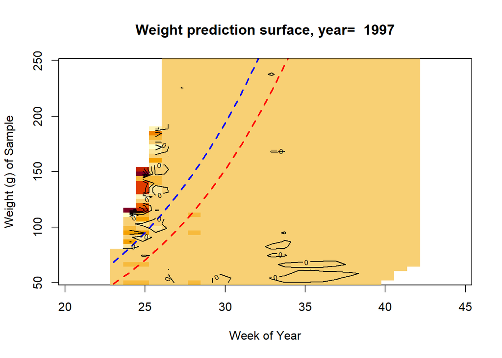

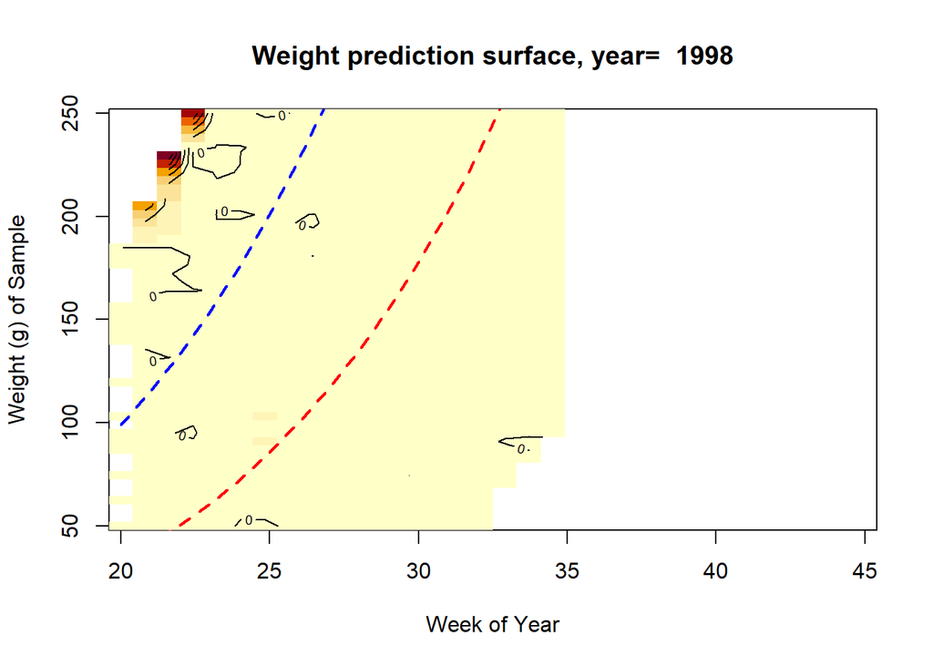

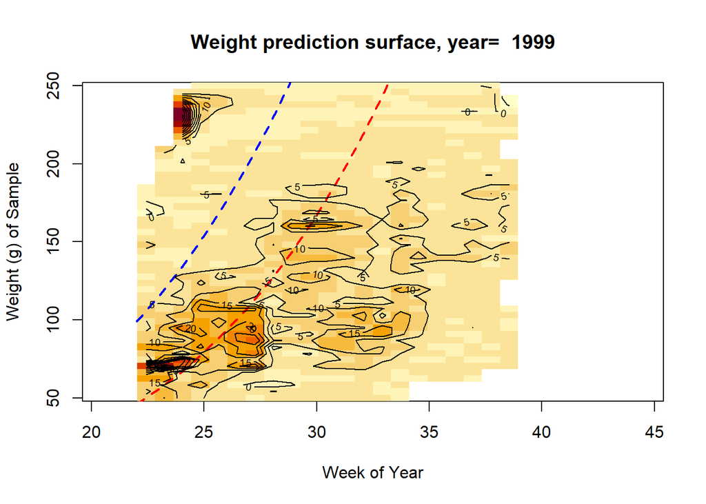

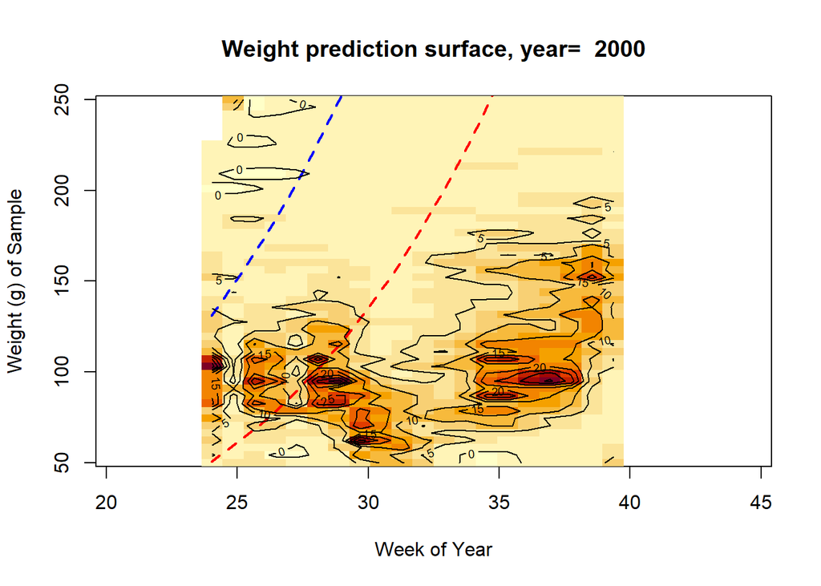

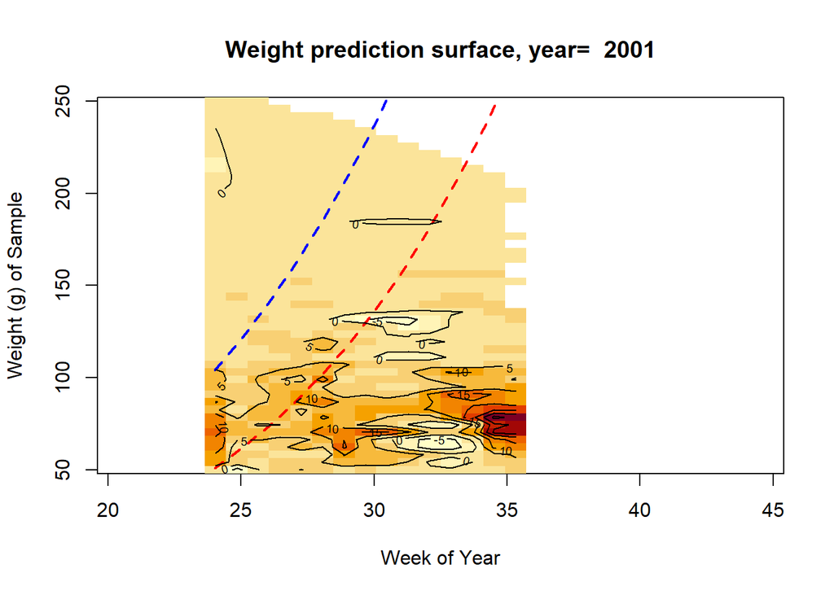

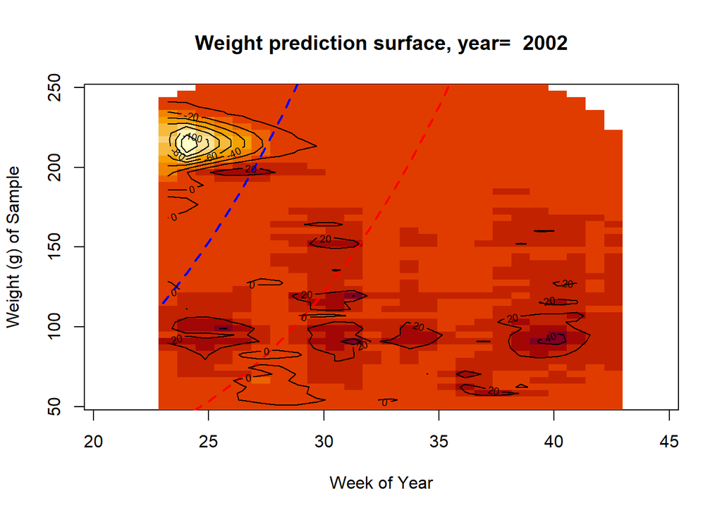

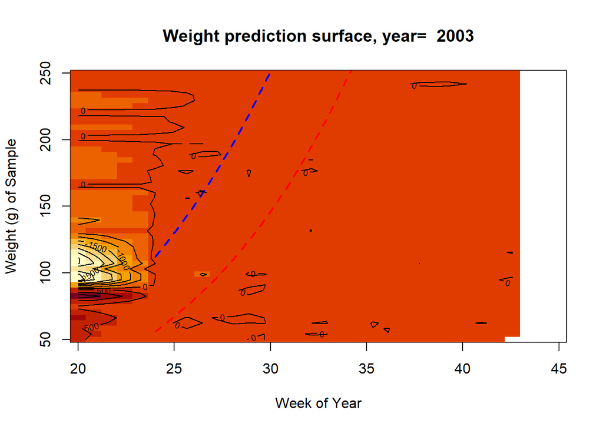

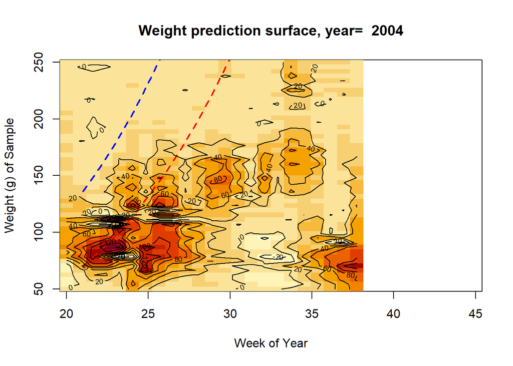

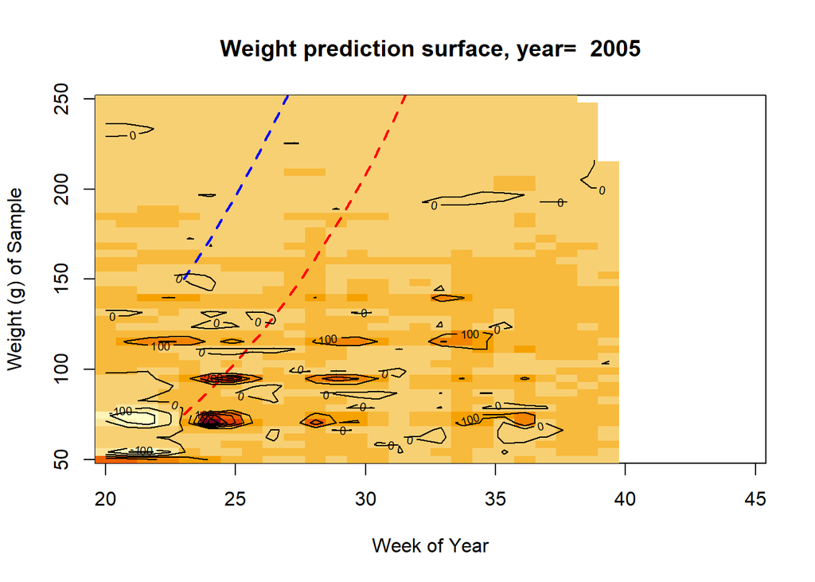

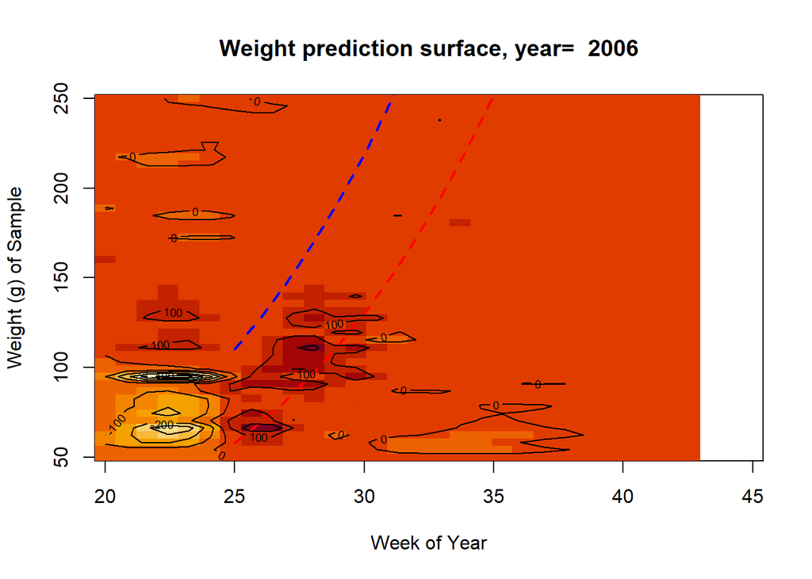

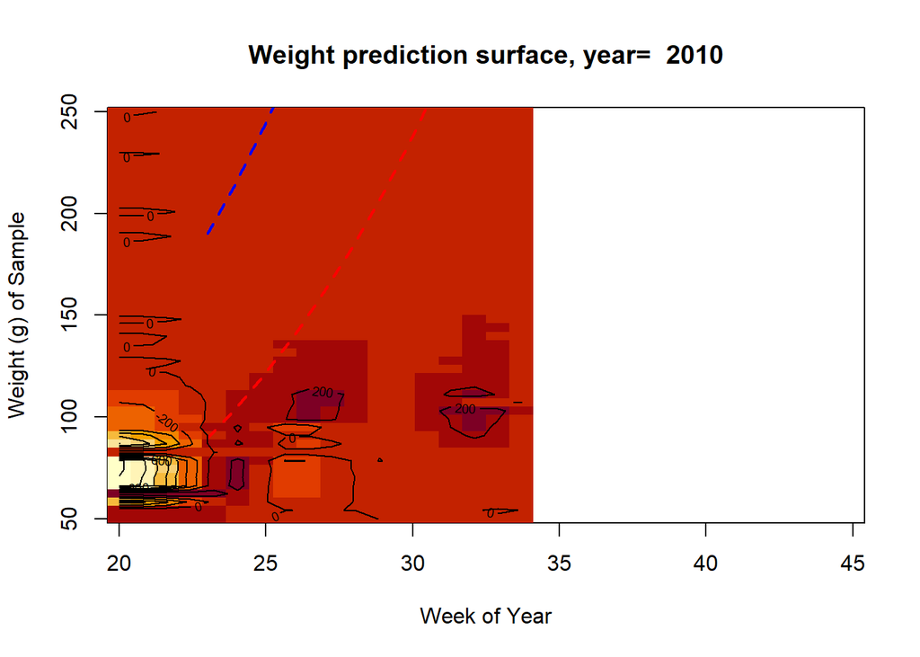

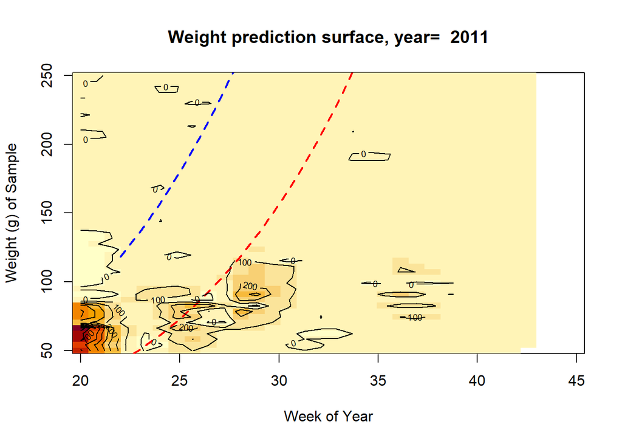

[10 more figures not shown]

```r
# From Rago_21 Methods: Weight (W) as a function of age (A)
# was modeled in Hendrickson and Hart as $$ W = \alpha Age^{\beta} $$, where
# $$ \alpha = 1.12 * 10^{-6} $$ and $$ \beta = 3.60 $$. These parameters were
# used to describe both male and female Illex combined, but the authors noted
# that sex specific differences did occur. The inverse of the weight at age
# function can be written as: Together these functions can be used to compute the projected growth of a cohort sampled
# by the fishery in any given week. The projected growth of an squid of size
# $$ W_{t} $$ to size $$ W_{t+1} $$ in week $ t+1 $ was obtained by first estimating its age in days, then adding 7 days to project it to the next week.
#  $$ Age_{t} = (W_{t} /\alpha)^{1/\beta} $$, thus the projected weight at time
#  $ t $ is :  $$ W_{t+1} = \alpha(Age_{t}+ 7 days)^{\beta} $$
# The above equations can be used to compute the projected growth of a squid at
# time $ t $ over times $ t + 1 $,$ t + 2 $,$ t + 3 $, etc.


library(contourPlot)
library(TAM)
library(Hmisc)
library(akima)
# Using weight data:

df <- bwts %>%
  group_by(year, week) %>% # May want to include stat_area for future analyses?
 # mutate(weight = round(BODYWT)) %>%
  count(BODYWT)
df <- df %>%
  rename(freq = n)
alpha<-1.12e-6
beta<-3.60

df$age.est<-round(df$BODYWT/alpha)^(1/beta)
#
# sampfreq.by.week.yr<-tapply(df$freq, list(df$year,df$week), sum)
#
# wtfreq.by.week.yr<-tapply(df$freq[df$year==2021],
#                           list(df$BODYWT[df$year==2021],
#                                df$week[df$year==2021]), sum)
# agefreq.by.week.yr<-tapply(df$freq[df$year==2021],
#                            list(df$age.est[df$year==2021],
#                                 df$week[df$year==2021]), sum)



# contour plots for Weight

nx<-sum(range(bwts$week))

nx<-32 # number of weeks
ny<-50 #
# year.seq<-c(min(bwts$year):max(bwts$year)), this avoids 'magic numbers' but
# since there are gaps in the data it has to be as below
# range(df$BODYWT)
# range(bwts$BODYWT)

year.seq<-c(1997:2006, 2010:2019, 2021:2022)
for (i in year.seq){
  ### save the plots to a set of png files
  #name1= paste0(getwd(),"/weight.plots.")
  # num=iyear
  # ext = ".png"
  #  path3 = paste0(name1,num,ext)
  #  png(file=path3)
  tmp <- df %>% filter(year == i)
 # iyear<-2022
  yy<-interp(tmp$week,
             tmp$BODYWT,
             tmp$freq,
             xo=seq(20,45, length=nx),
             yo=seq(50,250,length=ny),
             nx=nx, ny=ny, linear=FALSE,extrap=FALSE, duplicate ="mean")
  image(yy, main=paste("Weight prediction surface, year= ",i),
        xlab="Week of Year", ylab="Weight (g) of Sample")
  # find first week greater than or equal to 20.
  min.wk <- tmp$week[which(tmp$week>=20)[1]]
  wgt.est.quantiles<-wtd.quantile(df$BODYWT[df$year==i & df$week==min.wk],
                                  w=df$freq[df$year==i & df$week==min.wk],
                                  probs=c(0.05,0.1,0.9))

  # compute vectors of projections of computed weights for the 10%ile and 90%ile of initial weight
  x.week=seq(from=min.wk, to= 45)
  # plot the growth trajectory for 10th percentile of weight sample in initial week = min.wk
  age.10wgt<-(wgt.est.quantiles[1]/alpha)^(1/beta)
  proj.wt.10<-alpha* (age.10wgt+ 7*(x.week - min.wk))^beta
  lines(x.week,proj.wt.10, col="red",lty=2, lwd=2)

  # plot the growth trajectory for 90th percentile of weight sample in initial week = min.wk
  age.90wgt<-(wgt.est.quantiles[3]/alpha)^(1/beta)
  proj.wt.10<-alpha* (age.90wgt+ 7*(x.week - min.wk))^beta
  lines(x.week,proj.wt.10, col="blue",lty=2, lwd=2)
  contour(yy,add=TRUE)    #,nlevels = 5)
}
```

### Analysis of putative Birth weeks

Compute birth week as function of age at capture and then plot frequency of squid in sample:

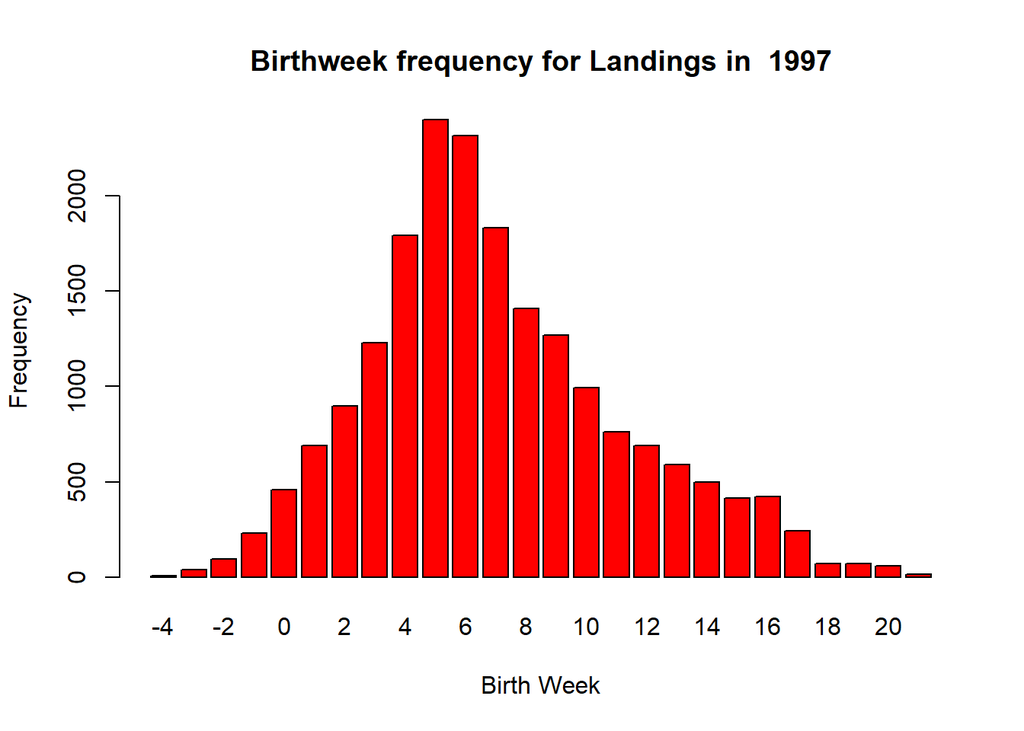

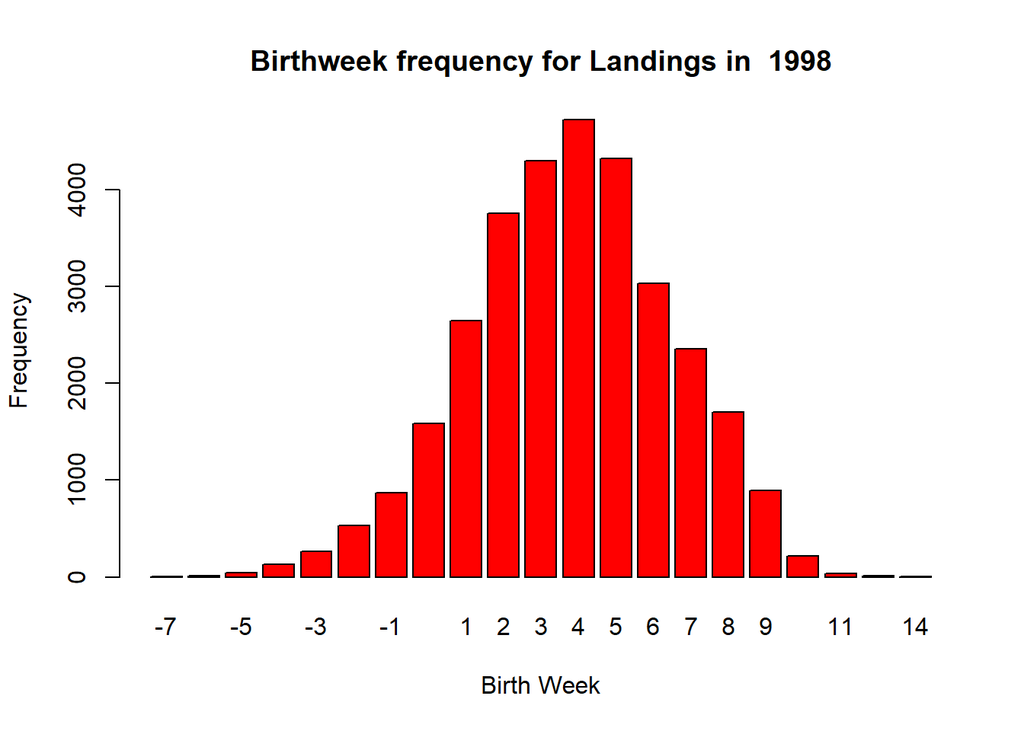

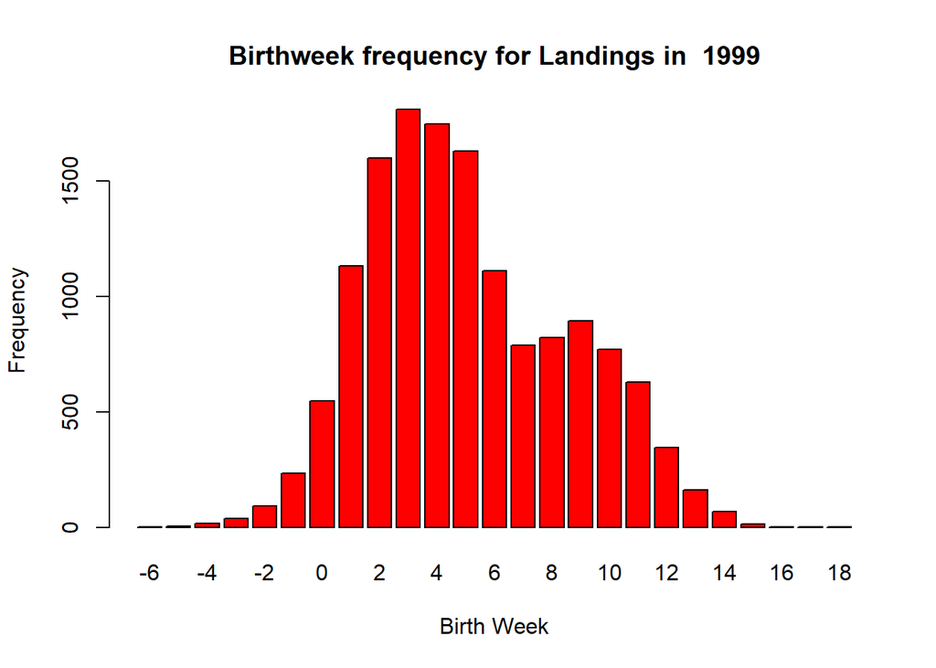

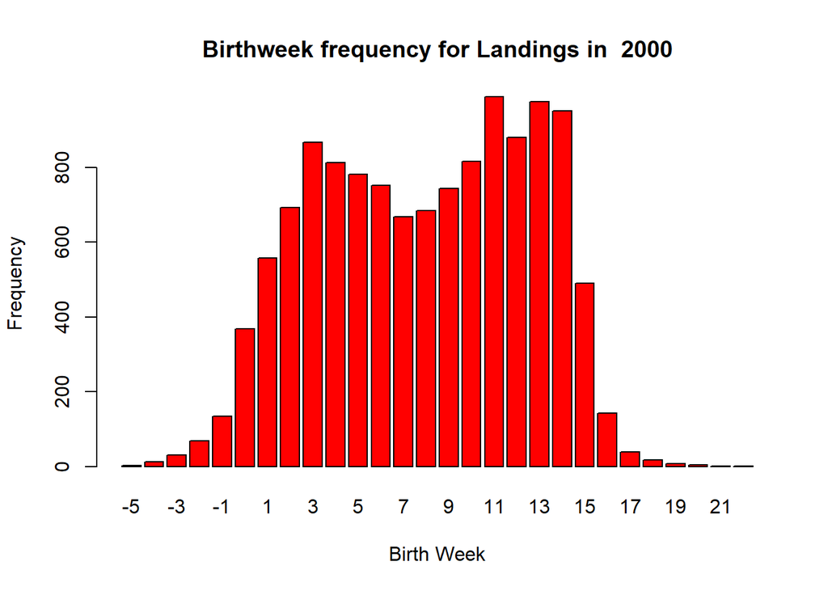

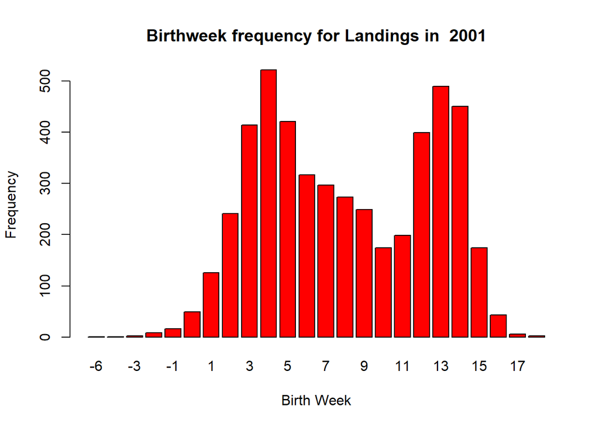

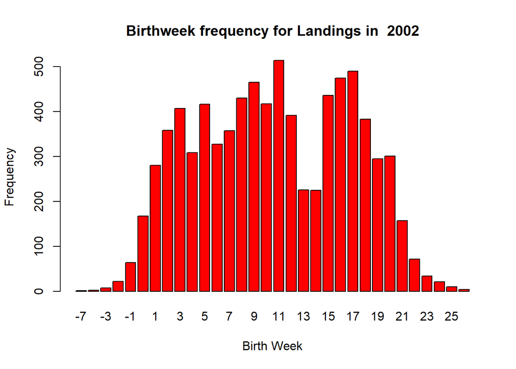

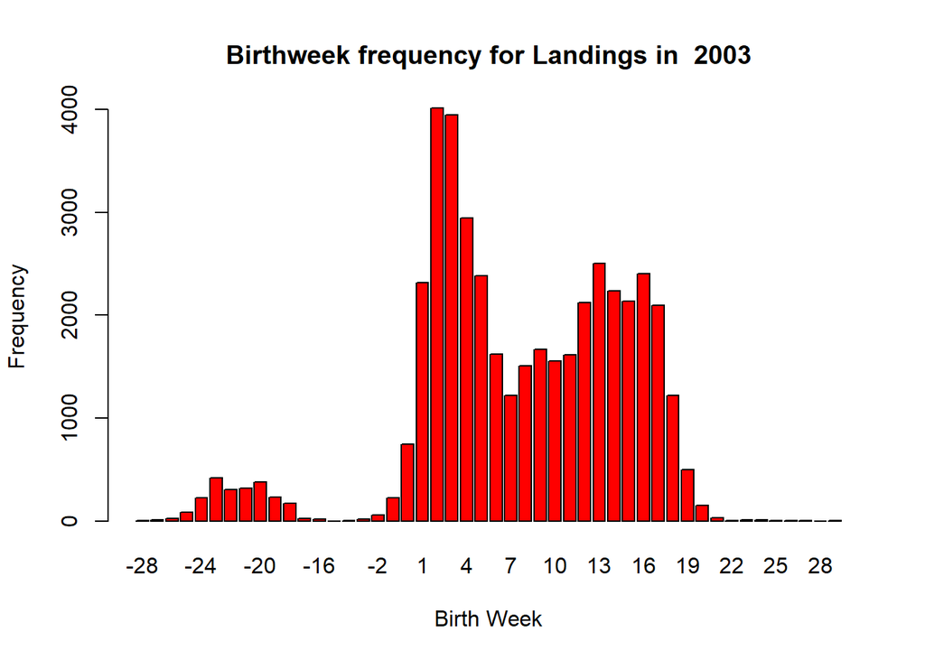

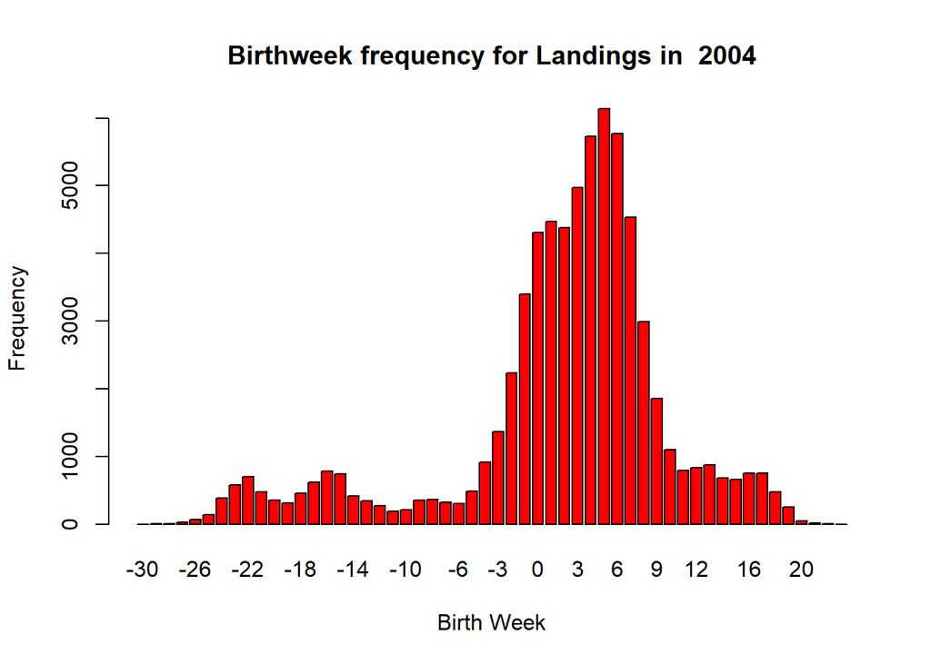

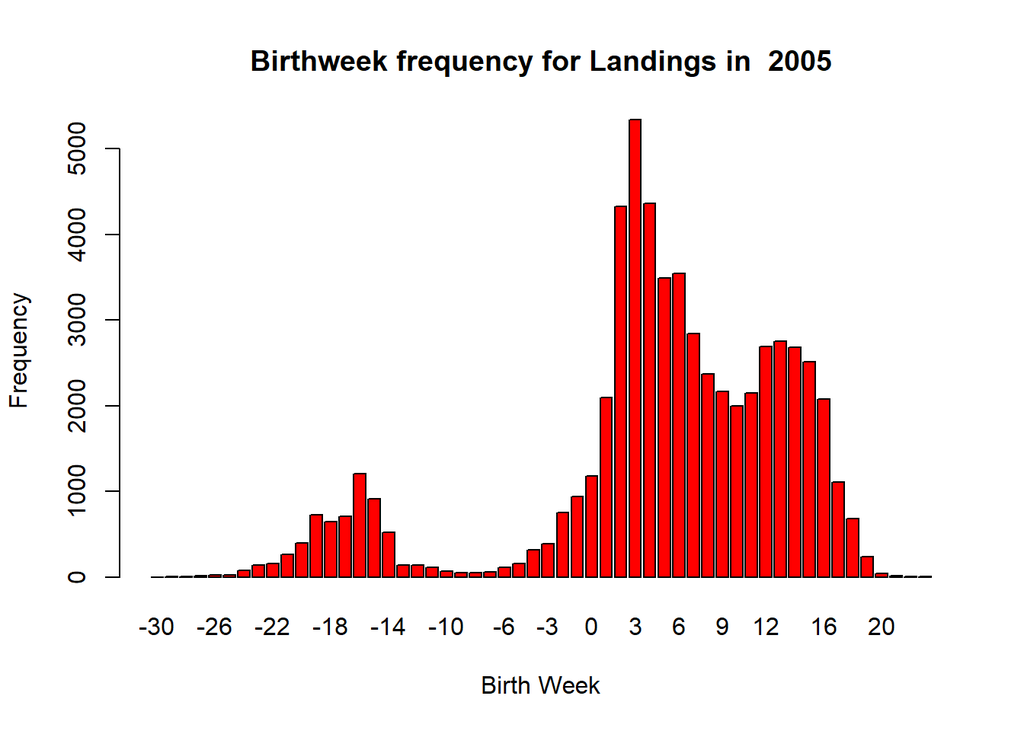

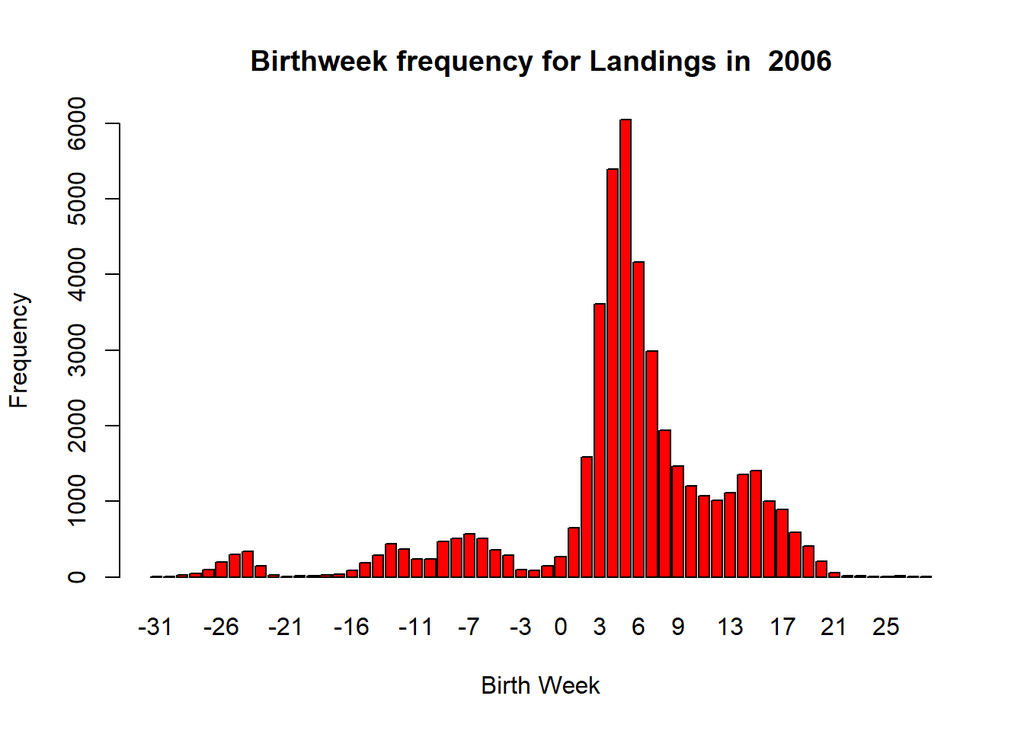

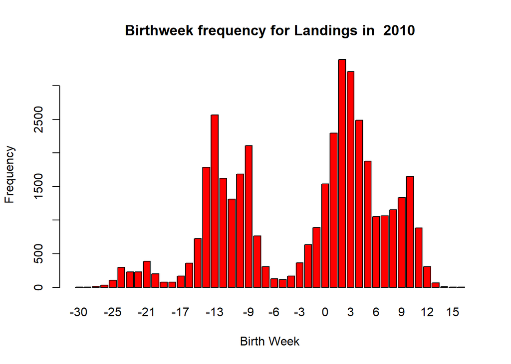

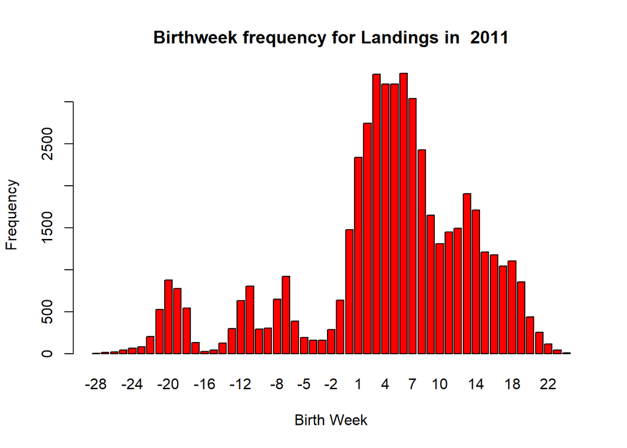

[10 more figures not shown]

```r
# Compute birth week as function of age at capture
#df <- as.data.frame(df)
df$birth.week<-round(df$week-df$age.est/7)
#  Plot frequency of birth weeks based on frequency of fish in sample.
b.week<-seq(from=min(df$birth.week), to = max(df$birth.week))
for (i in year.seq){
  tmp <- df %>% filter(year == i)
  b.week.table<-tapply(tmp$freq,tmp$birth.week, sum)
 barplot(b.week.table, main=paste("Birthweek frequency for Landings in ", i),
         xlab="Birth Week", ylab="Frequency", col="red")
 }
```

Adjusting birth week frequencies for natural mortality. This uses an M of 0.06, this may need to be adjusted/updated.

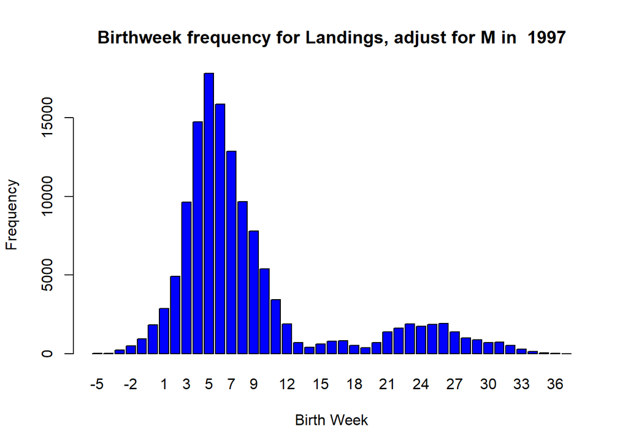

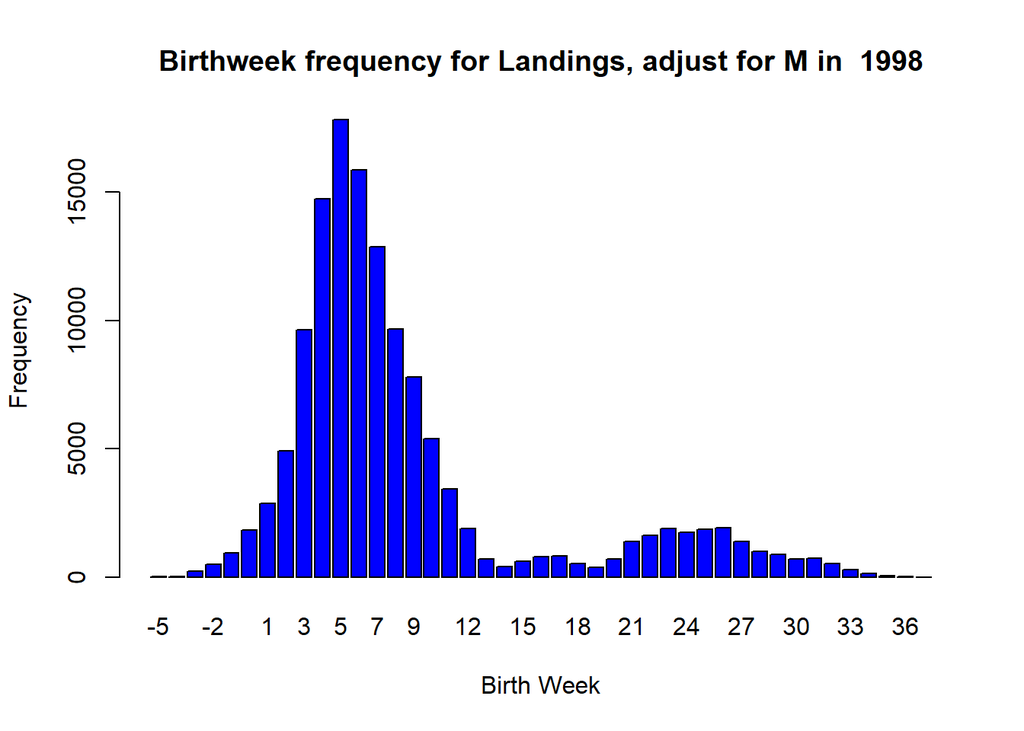

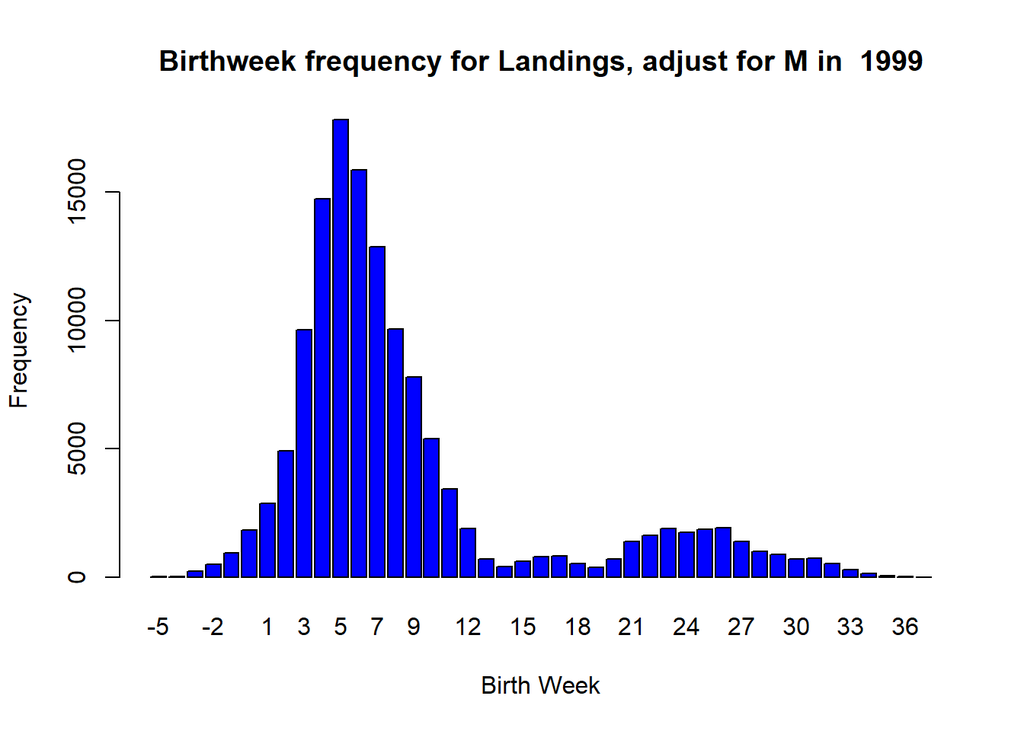

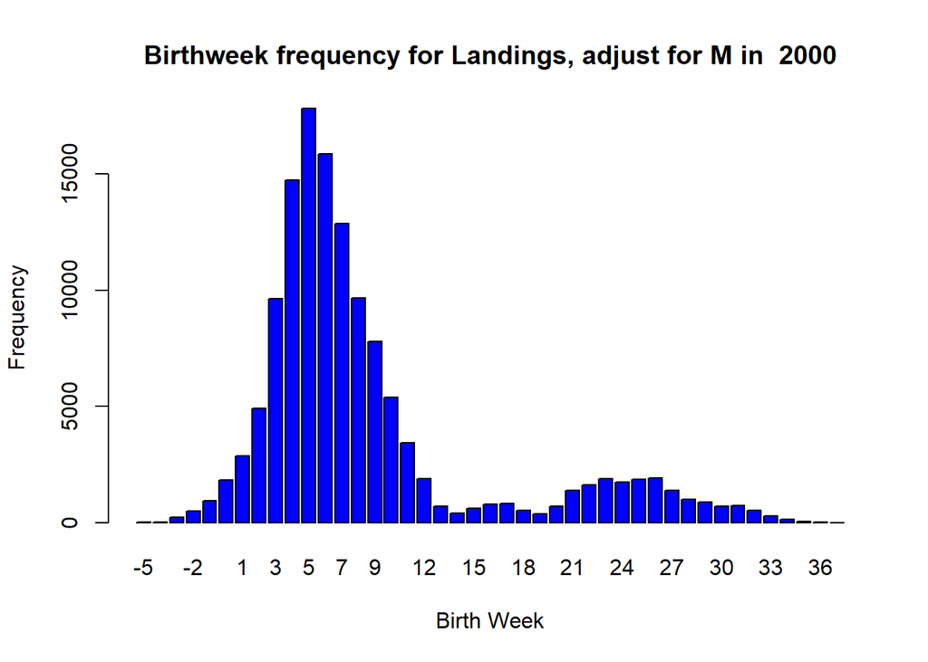

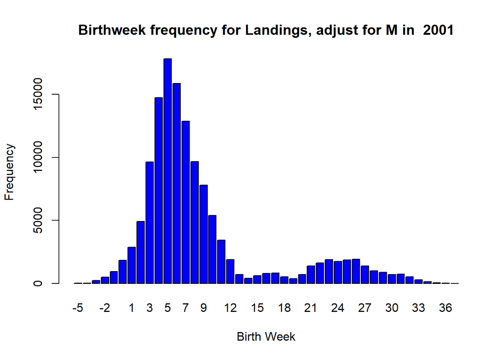

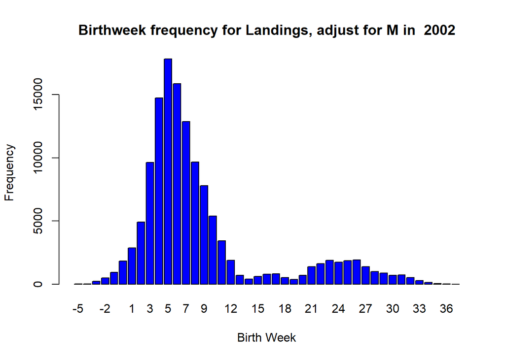

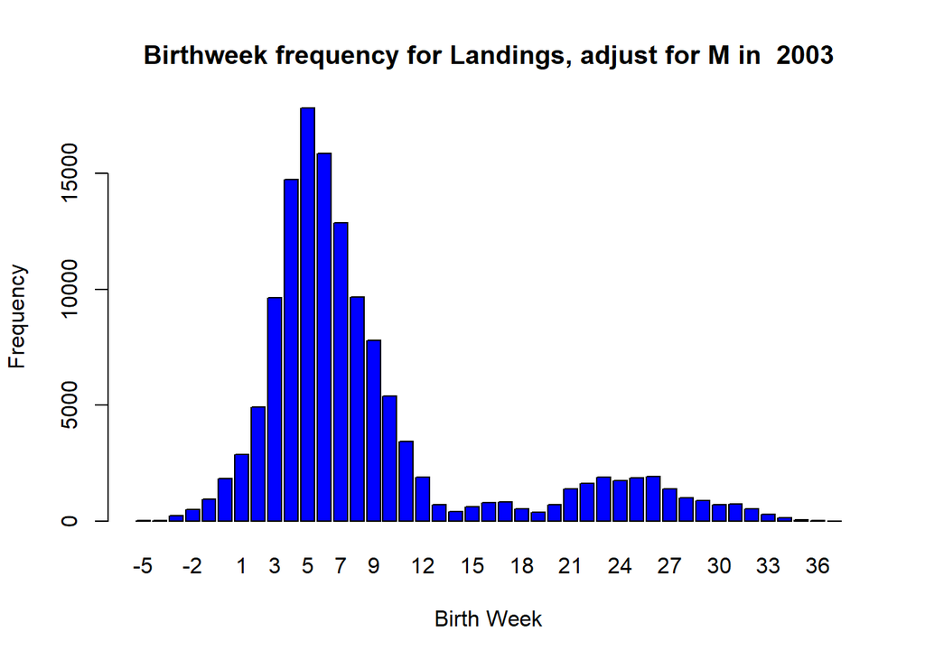

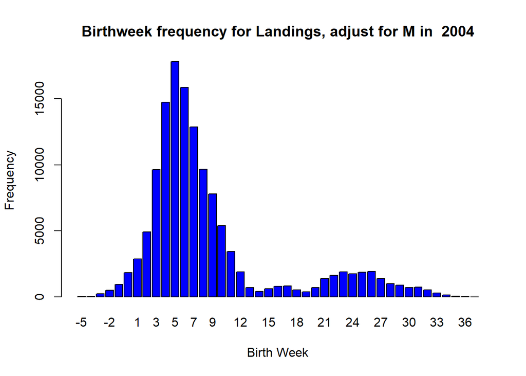

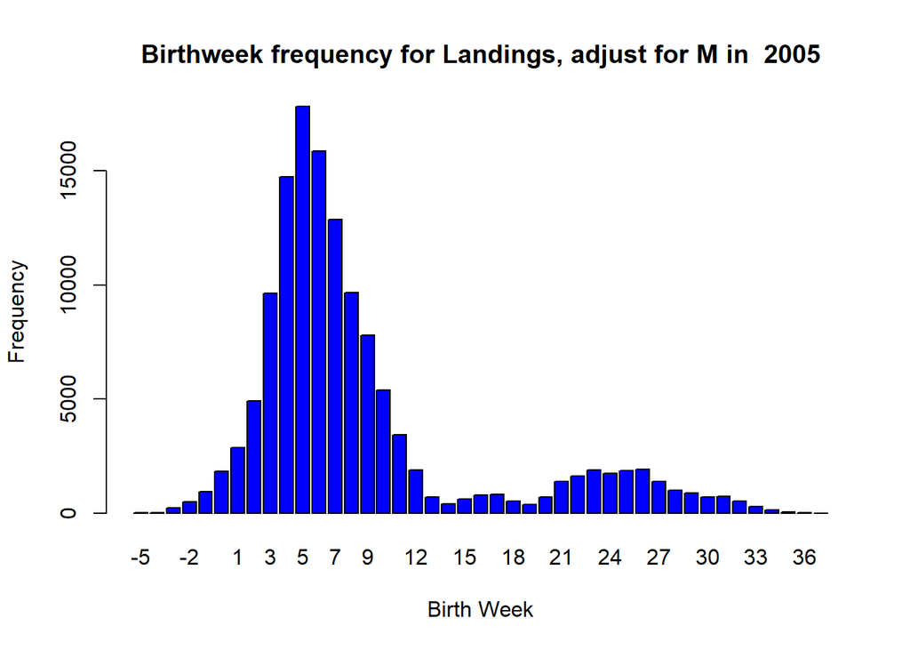

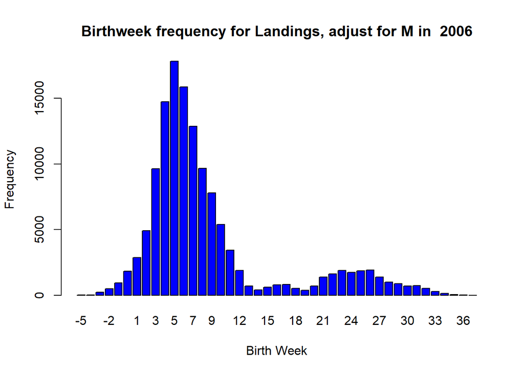

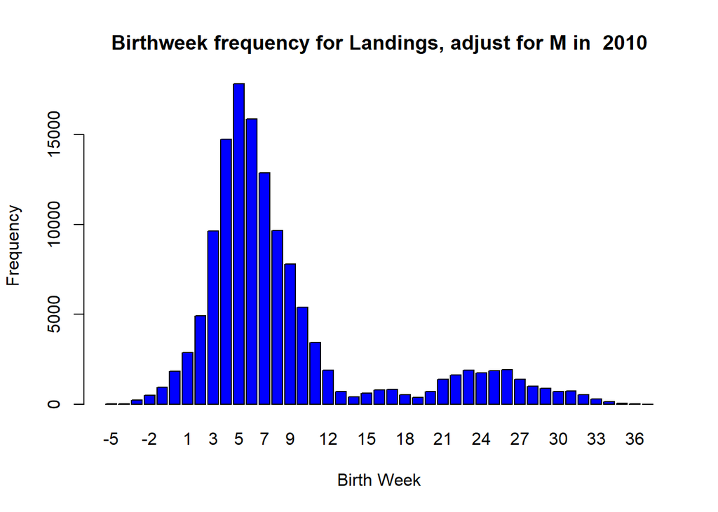

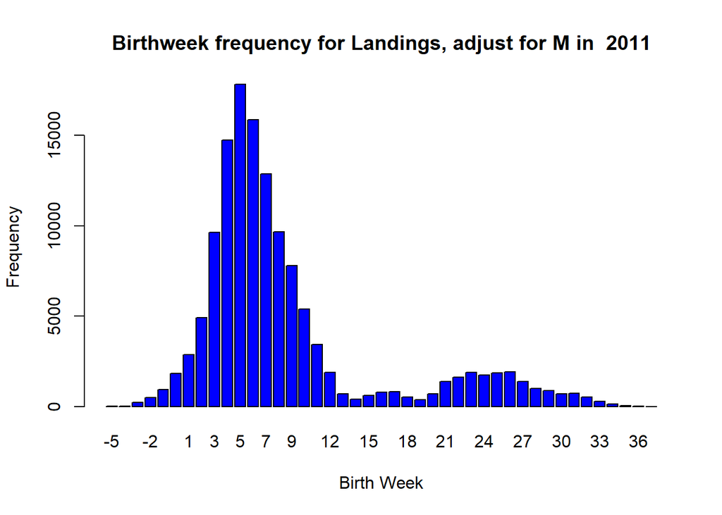

[10 more figures not shown]

```r
# adjust birth week frequencies for natural mortality
M <- 0.06   # natural mortality per week.   To be addressed later

for (i in year.seq){
  b.week.table<-tapply(tmp$freq* exp(tmp$age.est/7*M),
                       list(tmp$birth.week),
                       sum)
  barplot(b.week.table, main=paste("Birthweek frequency for Landings, adjust for M in ", i),
          xlab="Birth Week", ylab="Frequency", col="blue")
}
```

## Relative Condition

Condition estimates often based on length-weight relationships. Below is a plot of the the length weight relationship between all paired samples from the ILXSM data.

Regression coefficients were estimated from this current data set in effort to compare to length-weight relationships based on 1978 Lange and Johnson study.

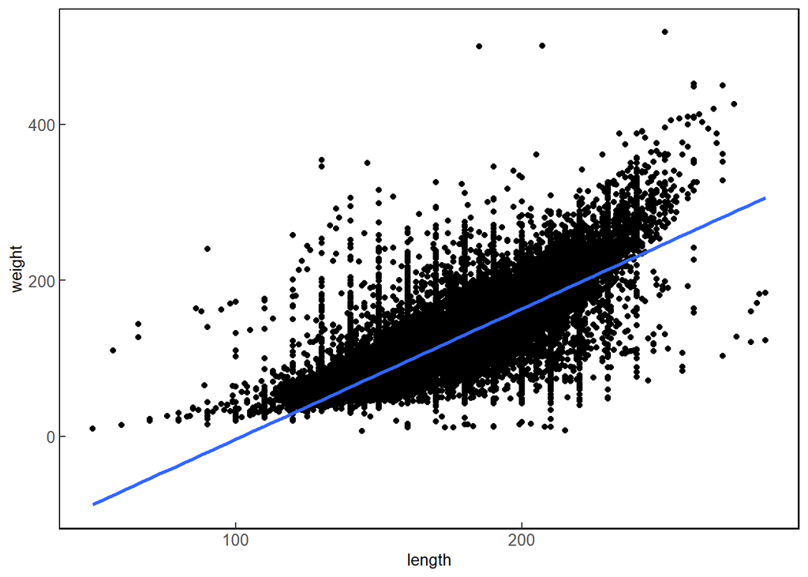

```r
# Calculate new coeffients with current data
# run regression
# mod <-lm(log(lw_paired$weight)~log(lw_paired$length/10))
# # Extract coefficients
# coef(mod) # intercept (alpha) and slope (beta) of the line
# # intercept is -2.300349 and the slope  2.463418 (cm)
# # Back transform alpha
# # e = 2.7182818
# # e^-2.300349
# exp(-2.300349)

g = ggplot(lw_paired, aes(x=length, y=weight)) +
  geom_point() +
  geom_smooth(method=lm) +
  ecodata::theme_ts()

g + theme(axis.text = element_text(size = 10),
        axis.title = element_text(size = 10),
        axis.ticks.length = unit(-1.4, "mm"))
```

```r
# ggplot(lw_paired, aes(x=log(length/10), y=log(weight))) +
#   geom_point()+
#   geom_smooth(method=lm) +
#   theme_bw()
```

Relative condition (Kn) = W/W`where W` is the predicted length-specific mean weight for the fish population in a given region

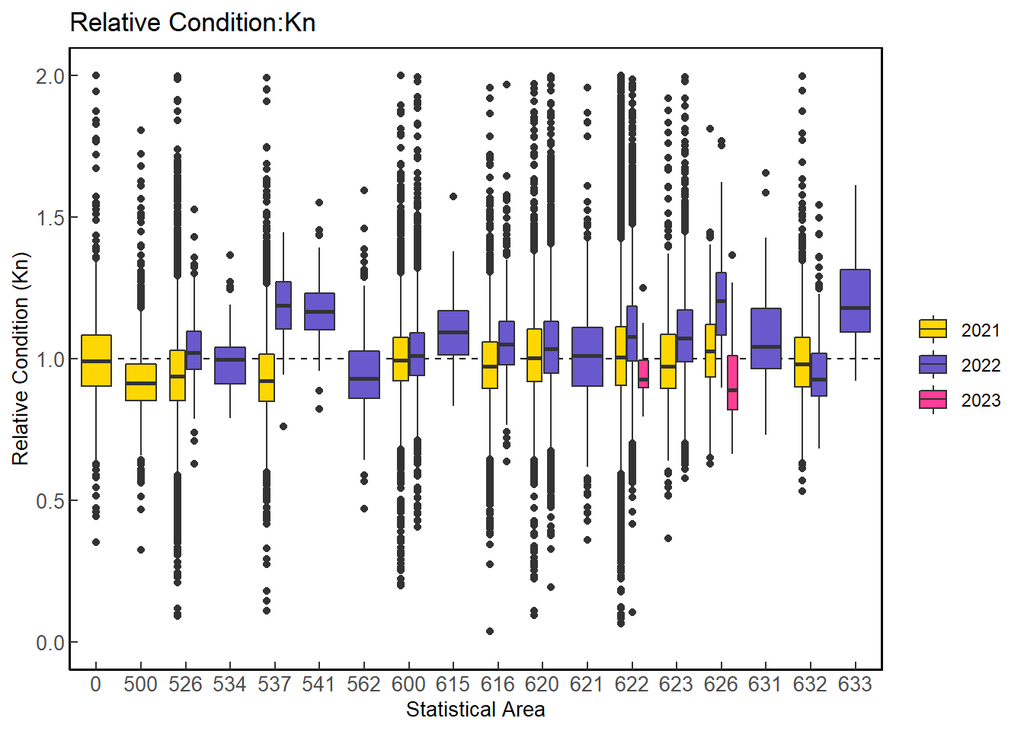

```r
# Two types of condition estimates
# -- Kn = W/W' --
# W = weight of individual squid,
# W' = predicted length-specific mean weight for the pop in a given region

# -- Fultons K =  100* W /L^3 -- #

### -- Compute relative condition -- ###
# compute length-weight relationships based on 1978 lange_johnson study:
lw_paired$W <- 0.04810*(lw_paired$length*.10)^2.71990
lw_paired$Kn <- lw_paired$weight/lw_paired$W
# lw_paired$W21 <- 0.082888*(lw_paired$length*.10)^2.530143
# lw_paired$W21 <- 0.1002239*(lw_paired$length*.10)^2.463418 ** on full data set

# lw_paired$Kn21 <- lw_paired$weight/lw_paired$W21
lw_paired$fk <- 100 * (lw_paired$weight/(lw_paired$length^3))



g  = ggplot(lw_paired,
            aes(x = factor(AREA_CODE), y = Kn, fill = as.factor(year)))+
  labs(x = 'Statistical Area', y = 'Relative Condition (Kn)',
       title = 'Relative Condition:Kn') +
  theme_classic() +
  guides(fill=guide_legend(title=NULL))+
  geom_hline(yintercept = 1, lty = 2) +
  ylim(0,2) +
  geom_boxplot() +
  scale_fill_manual(values=c('gold1','slateblue3','violetred1')) +
 ecodata::theme_ts()

g + theme(axis.text = element_text(size = 10),
        axis.title = element_text(size = 10),
        axis.ticks.length = unit(-1.4, "mm"))
```

Condition of catch within Freezer Trawler and Wet Boat fleets across years:

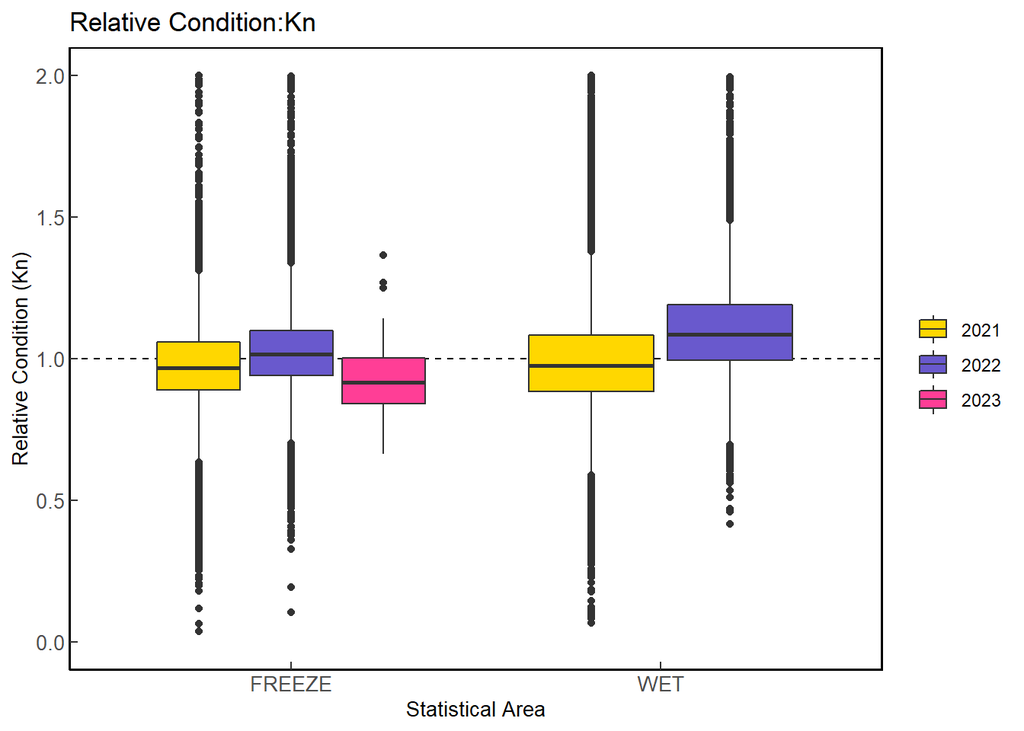

```r
## ------ NOTE -------- ##
# Look at relative condition by week or month and by fleet
# For some of the fleet info - there are NA's
# unique(lw_paired$fleet)
# Remove NAs:
check = na.omit(lw_paired)

g = ggplot(check,
            aes(x = factor(fleet), y = Kn, fill = as.factor(year)))+
  labs(x = 'Statistical Area', y = 'Relative Condition (Kn)',
       title = 'Relative Condition:Kn') +
  theme_classic() +
  guides(fill=guide_legend(title=NULL))+
  geom_hline(yintercept = 1, lty = 2) +
  ylim(0,2) +
  geom_boxplot() +
   scale_fill_manual(values=c('gold1','slateblue3','violetred1')) +
  ecodata::theme_ts()

g + theme(axis.text = element_text(size = 10),
        axis.title = element_text(size = 10),
        axis.ticks.length = unit(-1.4, "mm"))
```

Condition of catch during fishing season across years:

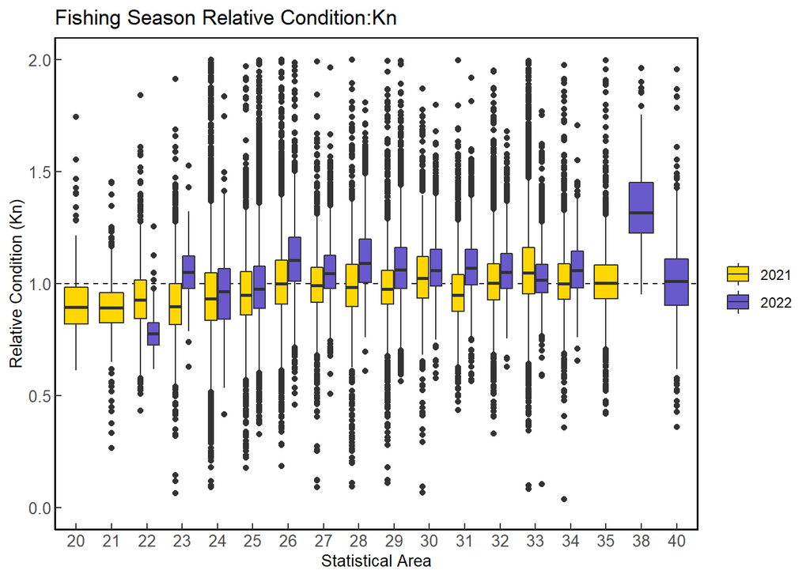

```r
g1 = ggplot(lw_paired %>% filter(week %in% c(20:40)),
            aes(x = factor(week), y = Kn, fill = as.factor(year)))+
  labs(x = 'Statistical Area', y = 'Relative Condition (Kn)',
       title = 'Fishing Season Relative Condition:Kn') +
  theme_classic() +
  guides(fill=guide_legend(title=NULL))+
  geom_hline(yintercept = 1, lty = 2) +
  ylim(0,2) +
  geom_boxplot() +
  scale_fill_manual(values=c('gold1','slateblue3','violetred1')) +
  ecodata::theme_ts()

g1 + theme(axis.text = element_text(size = 10),
        axis.title = element_text(size = 10),
        axis.ticks.length = unit(-1.4, "mm"))
```

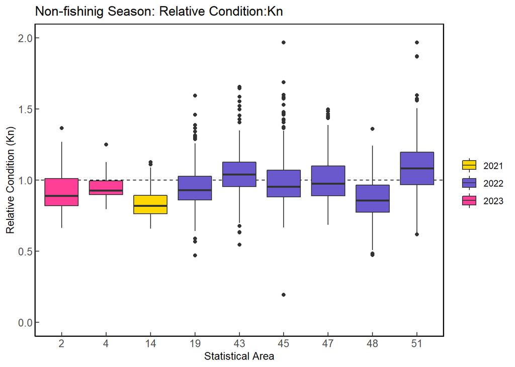

```r
g2 = ggplot(lw_paired %>% filter(week %in% c(2:19, 41:51)),
            aes(x = factor(week), y = Kn, fill = as.factor(year)))+
  labs(x = 'Statistical Area', y = 'Relative Condition (Kn)',
       title = 'Non-fishinig Season: Relative Condition:Kn') +
  theme_classic() +
  guides(fill=guide_legend(title=NULL))+
  geom_hline(yintercept = 1, lty = 2) +
  ylim(0,2) +
  geom_boxplot() +
   scale_fill_manual(values=c('gold1','slateblue3','violetred1')) +
  ecodata::theme_ts()

g2 + theme(axis.text = element_text(size = 10),
        axis.title = element_text(size = 10),
        axis.ticks.length = unit(-1.4, "mm"))
```

```r
# # Here I used mean weight of population (not length specific)
# g0 = ggplot(dat,
#             aes(x = factor(AREA_CODE), y = pop_kn, fill = as.factor(year)))+
#   labs(x = 'Statistical Area', y = 'Relative Condition (Kn)',
#        title = 'Relative Condition:',
#        subtitle = 'Based on mean weight of population') +
#   theme_classic() +
#   guides(fill=guide_legend(title=NULL))+
#   geom_hline(yintercept = 1, lty = 2) +
#   ylim(0,2) +
#   geom_boxplot()
# ggsave(path = here::here('results'),"Relative_condition_by_stat_area.jpg",
#        width = 8, height = 3.75, units = "in", dpi = 300)
# library(patchwork)
# g1 = ggplot(dat.check,
#        aes(x = factor(AREA_CODE), y = Kn, fill = as.factor(year)))+
#   labs(x = 'Statistical Area', y = 'Relative Condition (Kn)',
#        title = 'Relative Condition (Kn):',
#        subtitle = 'Based on 1970s regression coefficients') +
#   theme_classic() +
#   guides(fill='none')+
#   #guides(fill=guide_legend(title=NULL))+
#   geom_hline(yintercept = 1, lty = 2) +
#   ylim(0,2) +
#   geom_boxplot() # %>% filter(Kn <= 4.5)
# g2 = ggplot(dat.check %>% filter(Kn.updated <= 6),
#        aes(x = factor(AREA_CODE), y = Kn.updated, fill = as.factor(year)))+
#   labs(x = 'Statistical Area', y = '',
#        title = 'Relative Condition (Kn):',
#        subtitle = 'Based on 2021/22 regression coefficients') +
#   theme_classic() +
#   guides(fill=guide_legend(title=NULL))+
#   geom_hline(yintercept = 1, lty = 2) +
#   geom_boxplot()
# ## Note - i changed the filter and/or ylim to play with scale, remove outliers
#
# g1 + g2
# ggsave(path = here::here('results'),"kn_1970s_vs_kn_2122.jpg",
#        width = 10, height = 6, units = "in", dpi = 300)
# g1 + g0
# ggsave(path = here::here('results'),"kn_vs_mean_condition_by_stat_area.jpg",
#        width = 10, height = 6, units = "in", dpi = 300)
# g1 + g0  # with ylim(0,2)
# ggsave(path = here::here('results'),"kn_vs_mean_condition_by_stat_area_zoom.jpg",
#        width = 10, height = 5, units = "in", dpi = 300)
#
# # Here I used length-specific weight of population
# ggplot(dat, aes(x = factor(AREA_CODE), y = Kn, fill = as.factor(year)))+
#   labs(x = 'Statistical Area', y = 'Relative Condition (Kn)',
#        title = '2021 vs 2022') +
#   theme_classic() +
#   guides(fill=guide_legend(title=NULL))+
#   geom_hline(yintercept = 1, lty = 2) +
#   geom_boxplot()
# # remove 626 as outlier and other outliers
# #  2021 622 and 526
# sa526 <- df21 %>% filter(AREA_CODE == 526)
# sa622 <- df21 %>% filter(AREA_CODE == 622)
# max(sa622$weights)
# max(sa526$weights)
# ggplot(dat %>% filter(AREA_CODE %in% c(622, 537, 632, 616, 526, 541, 623,
#                                          525, 600, 621, 615, 562)),
#        aes(x = factor(AREA_CODE), y = Kn, fill = as.factor(year)))+
#   labs(x = 'Statistical Area', y = 'Relative Condition (Kn)',
#        title = '2021 vs 2022') +
#   theme_classic() +
#   guides(fill=guide_legend(title=NULL))+
#   geom_hline(yintercept = 1, lty = 2) +
#   geom_boxplot()
# ggplot(dat %>% filter(AREA_CODE %in% c(622, 537, 632, 616, 526, 541, 623,
#                                        525, 600, 621, 615, 562) &
#                         weights < 100),
#        aes(x = factor(AREA_CODE), y = Kn, fill = as.factor(year)))+
#   labs(x = 'Statistical Area', y = 'Relative Condition (Kn)',
#        title = '2021 vs 2022') +
#   theme_classic() +
#   guides(fill=guide_legend(title=NULL))+
#   geom_hline(yintercept = 1, lty = 2) +
#   geom_boxplot()
# ggsave(path = here::here('results'),"Relative_condition_Kn_no_outlier_by_stat_area.jpg",
#        width = 8, height = 3.75, units = "in", dpi = 300)
#
# # 2021 boxplot of condition
# ggplot(df21, aes(x = factor(AREA_CODE), y = cond2, fill = as.factor(AREA_CODE)))+
#   labs(x = 'Statistical Area', y = 'Condition',
#        title = '2021') +
#   theme_classic() +
#   guides(fill=guide_legend(title=NULL))+
#   geom_hline(yintercept = 1, lty = 2) +
#   geom_boxplot()
# # 2022 boxplot of condition
# ggplot(df22, aes(x = factor(AREA_CODE), y = cond2, fill = as.factor(AREA_CODE)))+
#   labs(x = 'Statistical Area', y = 'Condition (k)',
#        title = '2022') +
#   theme_classic() +
#   guides(fill=guide_legend(title=NULL))+
#   geom_hline(yintercept = 1, lty = 2) +
#   geom_boxplot()
# # Year specific condition
# ggplot(df22, aes(x = factor(AREA_CODE), y = cond, fill = as.factor(AREA_CODE)))+
#   labs(x = 'Statistical Area', y = 'Condition (k)',
#        title = '2022') +
#   theme_classic() +
#   guides(fill=guide_legend(title=NULL))+
#   geom_hline(yintercept = 1, lty = 2) +
#   geom_boxplot()
#
# ggplot(df21, aes(x = factor(AREA_CODE), y = fk, fill = as.factor(AREA_CODE)))+
#   labs(x = 'Statistical Area', y = 'Fulton Body Condition (k)',
#        title = 'Fleet: Wet boats',
#        subtitle = 'Lengths') +
#   #scale_fill_manual(values = c("#F1BB7B","#FD6467")) +
#   theme_classic() +
#   guides(fill=guide_legend(title=NULL))+
#   geom_boxplot()
#
# ggplot(df21, aes(x = factor(hold_type), y = fk, fill = as.factor(hold_type)))+
#   labs(x = 'Statistical Area', y = 'Fulton Body Condition (k)',
#        title = 'Fleet: Wet boats') +
#   #scale_fill_manual(values = c("#F1BB7B","#FD6467")) +
#   theme_classic() +
#   guides(fill=guide_legend(title=NULL))+
#   geom_boxplot()
#
# ggplot(df21 %>% filter(week %in% c(25:26)),
#        aes(x = factor(week), y = fk, fill = as.factor(hold_type)))+
#   labs(x = 'Statistical Area', y = 'Fulton Body Condition (k)') +
#   theme_classic() +
#   guides(fill=guide_legend(title=NULL))+
#   geom_boxplot()
#
# ggplot(df21 %>% filter(hold_type %in% c('Ice', 'FT')),
#        aes(x = factor(week), y = fk, fill = as.factor(hold_type)))+
#   labs(x = 'Statistical Area', y = 'Fulton Body Condition (k)') +
#   theme_classic() +
#   guides(fill=guide_legend(title=NULL))+
#   geom_boxplot()
#
# ggplot(df21 %>% filter(AREA_CODE %in% c(622, 537, 632, 616, 526, 541, 623,
#                                         525, 600, 621, 615, 562)),
#        aes(x = factor(AREA_CODE), y = fk, fill = as.factor(hold_type)))+
#   labs(x = 'Statistical Area', y = 'Fulton Body Condition (k)') +
#   theme_classic() +
#   guides(fill=guide_legend(title=NULL))+
#   geom_boxplot()
#
# # small: <80 mm ML; medium: 80-120 mm ML; large: >120 mm ML
# ggplot(df21 %>% filter(lengths <= 80),
#        aes(x = factor(AREA_CODE), y = fk, fill = as.factor(AREA_CODE)))+
#   labs(x = 'Statistical Area', y = 'Fulton Body Condition (k)',
#        title = 'Small') +
#   theme_classic() +
#   guides(fill=guide_legend(title=NULL))+
#   geom_boxplot()
#
# ggplot(df21 %>% filter(lengths <= 80),
#        aes(x = factor(AREA_CODE), y = fk, fill = as.factor(AREA_CODE)))+
#   labs(x = 'Statistical Area', y = 'Fulton Body Condition (k)',
#        title = 'Small') +
#   theme_classic() +
#   guides(fill=guide_legend(title=NULL))+
#   geom_boxplot()
# #80- 120 interesting, <200 more like large
# ggplot(df21 %>% filter(lengths > 80 & lengths < 200),
#        aes(x = factor(AREA_CODE), y = fk, fill = as.factor(AREA_CODE)))+
#   labs(x = 'Statistical Area', y = 'Fulton Body Condition (k)',
#        title = 'Medium') +
#   theme_classic() +
#   guides(fill=guide_legend(title=NULL))+
#   geom_boxplot()
#
# ggplot(df21 %>% filter(lengths > 200),
#        aes(x = factor(AREA_CODE), y = fk, fill = as.factor(AREA_CODE)))+
#   labs(x = 'Statistical Area', y = 'Fulton Body Condition (k)',
#        title = 'Large') +
#   theme_classic() +
#   guides(fill=guide_legend(title=NULL))+
#   geom_boxplot()
#
# ggplot(df21 %>% filter(lengths <= 80),
#        aes(x = factor(AREA_CODE), y = fk, fill = as.factor(AREA_CODE)))+
#   labs(x = 'Statistical Area', y = 'Fulton Body Condition (k)',
#        title = 'Small') +
#   theme_classic() +
#   guides(fill=guide_legend(title=NULL))+
#   geom_boxplot()
#
# ggplot(k21 %>% filter(hold_type %in% c('RSW', 'Ice') & PARAM_VALUE_NUM <= 500),
#        aes(x = factor(vessel_id), y = PARAM_VALUE_NUM, fill = as.factor(year)))+
#   labs(x = 'Vessel', y = 'Mantle length (mm)',
#        title = 'Fleet: Wet boats',
#        subtitle = 'Lengths') +
#   scale_fill_manual(values = c("#F1BB7B","#FD6467")) +
#   theme_classic() +
#   guides(fill=guide_legend(title=NULL))+
#   geom_boxplot()
```